# Neurorep exploratory analysis

## Results

### Distribution of studies over journals

The records included in our dataset was published in 330 different journals. This is in line with our expectation that social neuroscience is a broad and loosely connected research field with a great number of subfield contained within.

Figure 1 displays the name and frequency of the 20 journals most frequently published in (*Peder draft note: We could also change this to be a table. Or we could turn the tables below into figures like this. Whatever helps readability the most.*). Unsurprisingly, two of the four journals from which all records were initially scraped were also among the most prominent journals in the final set of studies (Social Cognitive and Affective Neuroscience, and Social Neuroscience). Besides these two, the sample appears to be dominated by journals that are either general topic, (Plos ONE and PNAS) or general neuroscience/psychology (e.g. Neuroimage, Frontiers Psychology, Cortex). The lack of specialist journals in the top end of the frequency distribution is likely due to the fact that these journals only serve a smaller subsection of the larger community of social neuroscientists, while journals like Neuroimage and Plos ONE can, in principle, serve them all.

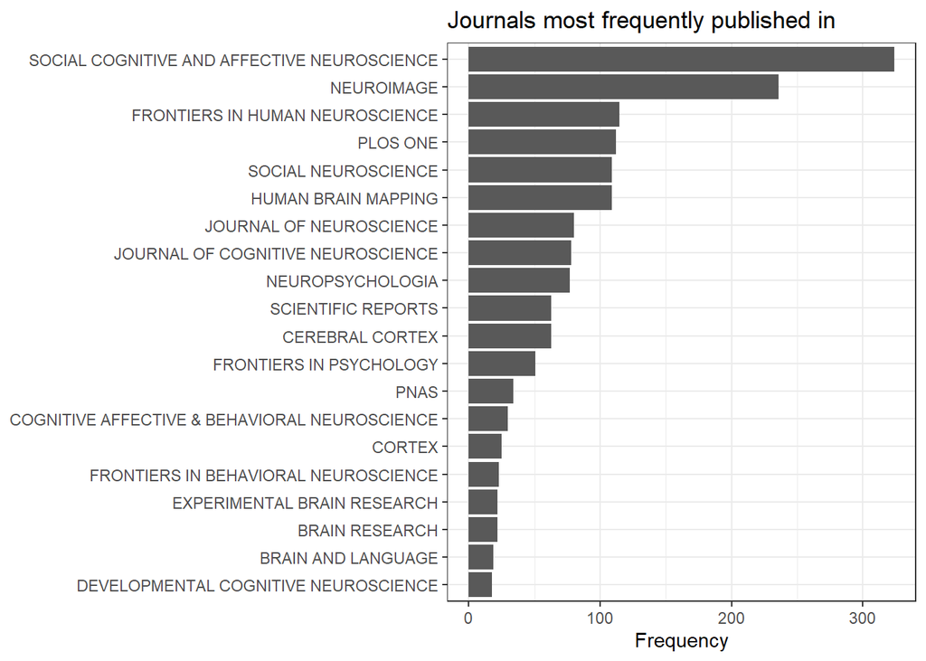

### Distribution of studies over Web of Science categories

The records in our dataset was classified as being members of 178 unique Web of Science categories. Table 1 displays the name and frequency of the 20 Web of Science categories most frequently tagged.

| field | frequency |
| --- | --- |
| Neurosciences; Neuroimaging; Radiology, Nuclear Medicine & Medical Imaging | 345 |
| Neurosciences; Psychology; Psychology, Experimental | 333 |
| Neurosciences | 291 |
| Neurosciences; Psychology | 225 |
| Multidisciplinary Sciences | 222 |
| Behavioral Sciences; Neurosciences | 112 |
| Neurosciences; Psychology, Experimental | 97 |
| Psychology, Multidisciplinary | 81 |
| Behavioral Sciences; Neurosciences; Psychology, Experimental | 77 |
| Psychology, Experimental | 38 |
| Psychology, Social | 27 |
| Audiology & Speech-Language Pathology; Linguistics; Neurosciences; Psychology, Experimental | 19 |
| Psychology, Developmental; Neurosciences | 18 |
| Endocrinology & Metabolism; Neurosciences; Psychiatry | 13 |
| Psychiatry | 13 |
| Psychology, Biological; Neurosciences; Physiology; Psychology; Psychology, Experimental | 12 |
| Anatomy & Morphology; Neurosciences | 10 |
| Neuroimaging | 10 |
| Neurosciences; Pharmacology & Pharmacy; Psychiatry | 10 |
| Neurosciences; Physiology | 9 |

### Citation clusters and frequently co-occuring keywords

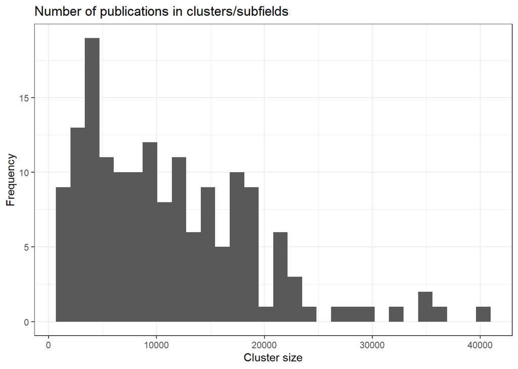

To better understand the scientific topic covered by these citation clusters, we inspected the category labels assigned to each cluster by CWTS. In total, the citation clusters were associated with 774 unique labels. Table 2 displays the frequency of the 50 most frequently mentioned category labels in our data.

Most frequent cluster labels

| label | frequency |
| --- | --- |
| intertemporal choice | 364 |
| decision making | 358 |
| delay discounting | 358 |
| impulsivity | 358 |
| iowa gambling task | 358 |
| imitation | 318 |
| action observation | 258 |
| empathy | 258 |
| mirror neuron | 258 |
| motor imagery | 258 |
| attentional bias | 210 |
| fear | 207 |
| emotional face | 203 |
| facial expression | 203 |
| social anxiety | 203 |
| default mode network | 180 |
| fmri | 180 |
| fmri data | 180 |
| functional connectivity | 180 |
| resting state | 180 |
| alzheimer | 125 |
| face processing | 118 |
| face recognition | 118 |
| facial identity | 118 |
| prosopagnosia | 118 |
| unfamiliar face | 118 |
| n400 | 109 |
| primary progressive aphasia | 109 |
| semantic dementia | 109 |
| visual word recognition | 109 |
| contamination | 67 |
| disgust | 67 |
| disgust sensitivity | 67 |
| moral dilemma | 67 |
| moral judgment | 67 |
| death anxiety | 65 |
| mind | 65 |
| mortality salience | 65 |
| ostracism | 65 |
| social exclusion | 65 |
| terror management | 65 |
| autobiographical memory | 63 |
| expressive writing | 63 |
| generativity | 63 |
| mental time travel | 63 |
| rumination | 63 |
| false belief | 60 |
| infant | 60 |
| month old infant | 60 |
| effect | 52 |

To complement the cluster information from CWTS, we utilized the VOSviewer analysis tool to extract topic-related keywords from article titles and abstracts, and analyze co-occurences between these keywords. Figure 3 displays the co-occurence map between commonly mentioned keywords in our dataset.

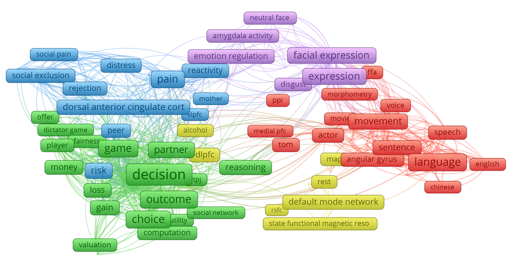

Figure 3: VOSviewer map of title/abstract keyword co-occurences